# Project: Investigate a Dataset - [TMDb movie data]

## Exploratory Data Analysis

### Research Question 1 (Which production companies of the movies has the heighst posibility of getting high popularity index?)

First, we will check how many production companies there in our dataset. We found that we have a lot of companies there (5182) which is a lot.

```python
print(df.production_companies.unique())
print(len(df.production_companies.unique()))
```

```
['Furthur Films' 'Little Stranger' 'RT Features' ..., 'V/M Productions'
 'Glen A. Larson Productions' 'The Cat in the Hat Productions']
5182
```

Because of that big number of companies, we decided that we will take the first biggest 30 popularity indexes and see if we find any relation between the companies there.

```python
# The biggest 30 companies
df30 = df.nlargest(n=30, columns=['popularity'])
# df30 = df
# df30
df30
```

|  | popularity | budget | director | runtime | genres | production_companies |
| --- | --- | --- | --- | --- | --- | --- |
| 6804 | 32.985763 | 150000000.0 | Colin Trevorrow | 124 | Action | Universal Studios |
| 11644 | 32.985763 | 150000000.0 | Colin Trevorrow | 124 | Adventure | Universal Studios |
| 17657 | 32.985763 | 150000000.0 | Colin Trevorrow | 124 | Action | Amblin Entertainment |
| 22497 | 32.985763 | 150000000.0 | Colin Trevorrow | 124 | Adventure | Amblin Entertainment |
| 6805 | 28.419936 | 150000000.0 | George Miller | 120 | Action | Village Roadshow Pictures |
| 11645 | 28.419936 | 150000000.0 | George Miller | 120 | Adventure | Village Roadshow Pictures |
| 17658 | 28.419936 | 150000000.0 | George Miller | 120 | Action | Kennedy Miller Productions |
| 22498 | 28.419936 | 150000000.0 | George Miller | 120 | Adventure | Kennedy Miller Productions |
| 7072 | 24.949134 | 165000000.0 | Christopher Nolan | 169 | Adventure | Paramount Pictures |
| 11912 | 24.949134 | 165000000.0 | Christopher Nolan | 169 | Drama | Paramount Pictures |
| 17925 | 24.949134 | 165000000.0 | Christopher Nolan | 169 | Adventure | Legendary Pictures |
| 22765 | 24.949134 | 165000000.0 | Christopher Nolan | 169 | Drama | Legendary Pictures |
| 7073 | 14.311205 | 170000000.0 | James Gunn | 121 | Action | Marvel Studios |
| 11913 | 14.311205 | 170000000.0 | James Gunn | 121 | Science Fiction | Marvel Studios |
| 17926 | 14.311205 | 170000000.0 | James Gunn | 121 | Action | Moving Picture Company (MPC) |
| 22766 | 14.311205 | 170000000.0 | James Gunn | 121 | Science Fiction | Moving Picture Company (MPC) |
| 6806 | 13.112507 | 110000000.0 | Robert Schwentke | 119 | Adventure | Summit Entertainment |
| 11646 | 13.112507 | 110000000.0 | Robert Schwentke | 119 | Science Fiction | Summit Entertainment |
| 17659 | 13.112507 | 110000000.0 | Robert Schwentke | 119 | Adventure | Mandeville Films |
| 22499 | 13.112507 | 110000000.0 | Robert Schwentke | 119 | Science Fiction | Mandeville Films |
| 27409 | 12.971027 | 170000000.0 | Joe Russo | 136 | Action | Marvel Studios |
| 27613 | 12.971027 | 170000000.0 | Joe Russo | 136 | Adventure | Marvel Studios |
| 29251 | 12.971027 | 170000000.0 | Anthony Russo | 136 | Action | Marvel Studios |
| 29455 | 12.971027 | 170000000.0 | Anthony Russo | 136 | Adventure | Marvel Studios |
| 7365 | 12.037933 | 11000000.0 | George Lucas | 121 | Adventure | Lucasfilm |
| 12205 | 12.037933 | 11000000.0 | George Lucas | 121 | Action | Lucasfilm |
| 18218 | 12.037933 | 11000000.0 | George Lucas | 121 | Adventure | Twentieth Century Fox Film Corporation |
| 23058 | 12.037933 | 11000000.0 | George Lucas | 121 | Action | Twentieth Century Fox Film Corporation |
| 27902 | 11.422751 | 20000000.0 | Chad Stahelski | 101 | Action | Thunder Road Pictures |
| 28209 | 11.422751 | 20000000.0 | Chad Stahelski | 101 | Thriller | Thunder Road Pictures |

```python
#The mean popularity in each
dfg = df30.groupby('production_companies', as_index=False)['popularity'].mean()
print(dfg)
```

```
                      production_companies  popularity
0                     Amblin Entertainment   32.985763
1               Kennedy Miller Productions   28.419936
2                       Legendary Pictures   24.949134
3                                Lucasfilm   12.037933
4                         Mandeville Films   13.112507
5                           Marvel Studios   13.417753
6             Moving Picture Company (MPC)   14.311205
7                       Paramount Pictures   24.949134
8                     Summit Entertainment   13.112507
9                    Thunder Road Pictures   11.422751
10  Twentieth Century Fox Film Corporation   12.037933
11                       Universal Studios   32.985763
12               Village Roadshow Pictures   28.419936
```

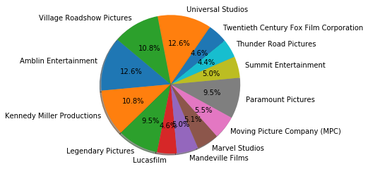

```python
#Plotting the mean popularity...
#some help from stackoverflow
labels = dfg.production_companies
sizes = dfg.popularity
plt.pie(sizes, labels=labels,
        autopct='%1.1f%%', shadow=True, startangle=140)
plt.axis('equal')
plt.show()
```

### Research Question 2 (What kinds of properties are associated with movies that have high, low and moderatr Budget requirments?)

First of all, We will add an addition column with the budget_rate, as we will divide the budget into low, medium and high.

```python
# View the min, 25%, 50%, 75%, max pH values with Pandas describe
df['budget'].describe()
```

```
count    3.102100e+04
mean     3.465422e+07
std      3.065688e+07
min      1.000000e+00
25%      1.800000e+07
50%      3.465422e+07
75%      3.465422e+07
max      4.250000e+08
Name: budget, dtype: float64
```

```python
# Bin edges that will be used to "cut" the data into groups
bin_edges = [ 1.000000e+00, 1.800000e+07, 3.465422e+07, 3.465423e+07, 4.250000e+08]
```

```python
# Labels for the four acidity level groups
bin_names = ['Low', 'Medium','Moderately', 'High']
```

```python
len(df.columns)
```

```
6
```

```python
# Creates budget_level column
df['budget_level'] = pd.cut(df['budget'], bin_edges, labels=bin_names)

# Checks for successful creation of this column
df.head()
```

|  | popularity | budget | director | runtime | genres | production_companies | budget_level |
| --- | --- | --- | --- | --- | --- | --- | --- |
| 0 | 2.272044 | 3.465422e+07 | Jean-Baptiste LÃ©onetti | 95 | Thriller | Furthur Films | Moderately |
| 1 | 1.376605 | 3.000000e+07 | Jason Moore | 118 | Comedy | Little Stranger | Medium |
| 2 | 1.293140 | 3.465422e+07 | Noah Baumbach | 84 | Comedy | RT Features | Moderately |
| 3 | 0.894477 | 3.465422e+07 | Andrew Haigh | 95 | Drama | The Bureau | Moderately |
| 4 | 0.836941 | 3.465422e+07 | James Ponsoldt | 106 | Drama | A24 | Moderately |

```python
len(df.columns)
```

```
7
```

By now, we have added the extra column for the budget level so that we can act upon, now we will dicover the variables one by one deeper.

**First** We will check if there is a relation between the runtime and the budget level....

```python
# The mean runtime of each budget level
dfg = df.groupby('budget_level')['runtime'].mean()
dfg
```

```
budget_level
Low           102.145962
Medium        110.087361
Moderately     97.857539
High          114.240361
Name: runtime, dtype: float64
```

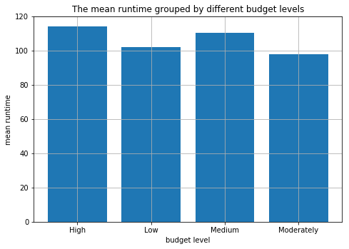

```python
# Plotting the datat to visualize
fig = plt.figure()
ax = fig.add_axes([0, 0, 1, 1])
levels = ['Low', 'Medium','Moderately', 'High']
students = [102.145962,110.087361,97.857539,114.240361]
ax.bar(levels,students)
plt.xlabel('budget level')
plt.ylabel('mean runtime')
plt.title('The mean runtime grouped by different budget levels')
plt.grid(True)
plt.show()
```

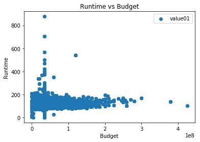

```python
plt.scatter(df['budget'], df['runtime'], label = "value01" )

plt.ylabel('Runtime')
plt.xlabel('Budget')

plt.title('Runtime vs Budget')
plt.legend()
plt.show()
```

Now We Are going to check if there is a relation between the budget and the movies geners, and which gener usually has the highest budget

first we will see how it looks like by the groupby method...

```python
dfg2 = df.groupby(['genres', 'budget_level'])['genres'].count()
dfg2
```

```
genres           budget_level
Action           Low              815
                 Medium           416
                 Moderately      1258
                 High            1044
Adventure        Low              373
                 Medium           223
                 Moderately       661
                 High             785
Animation        Low              125
                 Medium            48
                 Moderately       607
                 High             353
Comedy           Low             1246
                 Medium           563
                 Moderately      2518
                 High             795
Crime            Low              435
                 Medium           216
                 Moderately       479
                 High             277
Documentary      Low               85
                 Medium             4
                 Moderately       480
                 High               1
Drama            Low             1874
                 Medium           717
                 Moderately      3006
                 High             802
Family           Low              112
                 Medium            80
                                 ...
Music            Low              118
                 Medium            30
                 Moderately       226
                 High              37
Mystery          Low              170
                 Medium            96
                 Moderately       275
                 High              92
```

[output cut: 8 more lines]

```
TV Movie         Low               10
                 Moderately       113
Thriller         Low              759
                 Medium           260
                 Moderately      1066
                 High             373
War              Low               36
                 Medium            16
                 Moderately        94
                 High              50
Western          Low               30
                 Medium             8
                 Moderately        73
                 High              24
Name: genres, Length: 77, dtype: int64
```

We can't get a specifc relation from the above table, but we still can use the following chart to see:

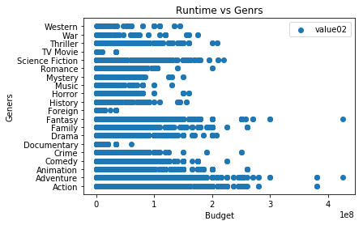

```python
plt.scatter(df['budget'], df['genres'], label = "value02" )

plt.ylabel('Geners')
plt.xlabel('Budget')

plt.title('Runtime vs Genrs')
plt.legend()
plt.show()
```

**We see from the chart that the action and adventure movies has a clear high possibility of spending more budget on them**

## Submitting your Project

> **Tip**: Before you submit your project, you need to create a .html or .pdf version of this notebook in the workspace here. To do that, run the code cell below. If it worked correctly, you should get a return code of 0, and you should see the generated .html file in the workspace directory (click on the orange Jupyter icon in the upper left).

> **Tip**: Alternatively, you can download this report as .html via the **File** > **Download as** submenu, and then manually upload it into the workspace directory by clicking on the orange Jupyter icon in the upper left, then using the Upload button.

> **Tip**: Once you've done this, you can submit your project by clicking on the "Submit Project" button in the lower right here. This will create and submit a zip file with this .ipynb doc and the .html or .pdf version you created. Congratulations!

```python
from subprocess import call
call(['python', '-m', 'nbconvert', 'Investigate_a_Dataset.ipynb'])
```

```
0
```